# Análisis Bioestadístico - Crecimiento de plantas in vitro

Alex Alvarez

2022-11-06

```r
pacman::p_load(tidyverse, corrplot, patchwork, hrbrthemes, ggpubr)
setwd('C:/Users/ALEX/OneDrive_main/UAI/CL/S2/Bioest/Bio_in_vitro')
db <- read_delim("Lab_veg.csv", delim = "\t",
    escape_double = FALSE, trim_ws = TRUE)
summary(db)
```

```
##    Largo_raiz      Area_foliar        Factor
##  Min.   :  3.00   Min.   :  3042   Length:108
##  1st Qu.: 31.00   1st Qu.: 27980   Class :character
##  Median : 44.00   Median : 83153   Mode  :character
##  Mean   : 49.68   Mean   :124558
##  3rd Qu.: 66.00   3rd Qu.:225163
##  Max.   :126.00   Max.   :413715
##  NA's   :35       NA's   :24
```

```r
glimpse(db)
```

```
## Rows: 108
## Columns: 3
## $ Largo_raiz  <dbl> 56, 72, 78, 56, 77, 77, 5, 55, 89, 57, 62, 56, 73, 58, 89,…
## $ Area_foliar <dbl> 28799, 14756, 22363, 31118, 14683, 28313, 3042, 24854, 228…
## $ Factor      <chr> "Control", "Control", "Control", "Control", "Control", "Co…
```

> Se observan 108 datos y la presencia de valores ausentes (NA). Tales observaciones no ayudarán al análisis, por lo que se decide quitarlos del set de datos.

Se quitan los valores ausentes

```r
db <- db%>% drop_na()
summary(db)
```

```
##    Largo_raiz      Area_foliar        Factor
##  Min.   :  3.00   Min.   :  3042   Length:69
##  1st Qu.: 31.00   1st Qu.: 28313   Class :character
##  Median : 42.00   Median : 87479   Mode  :character
##  Mean   : 49.38   Mean   :125798
##  3rd Qu.: 65.00   3rd Qu.:224199
##  Max.   :126.00   Max.   :413715
```

```r
glimpse(db)
```

```
## Rows: 69
## Columns: 3
## $ Largo_raiz  <dbl> 56, 72, 78, 56, 77, 77, 5, 55, 89, 57, 62, 56, 73, 58, 89,…
## $ Area_foliar <dbl> 28799, 14756, 22363, 31118, 14683, 28313, 3042, 24854, 228…
## $ Factor      <chr> "Control", "Control", "Control", "Control", "Control", "Co…
```

> El resultado es 69 observaciones sin valores ausentes.

Evaluación visual usando boxlpots

```
## notch went outside hinges. Try setting notch=FALSE.
## notch went outside hinges. Try setting notch=FALSE.
```

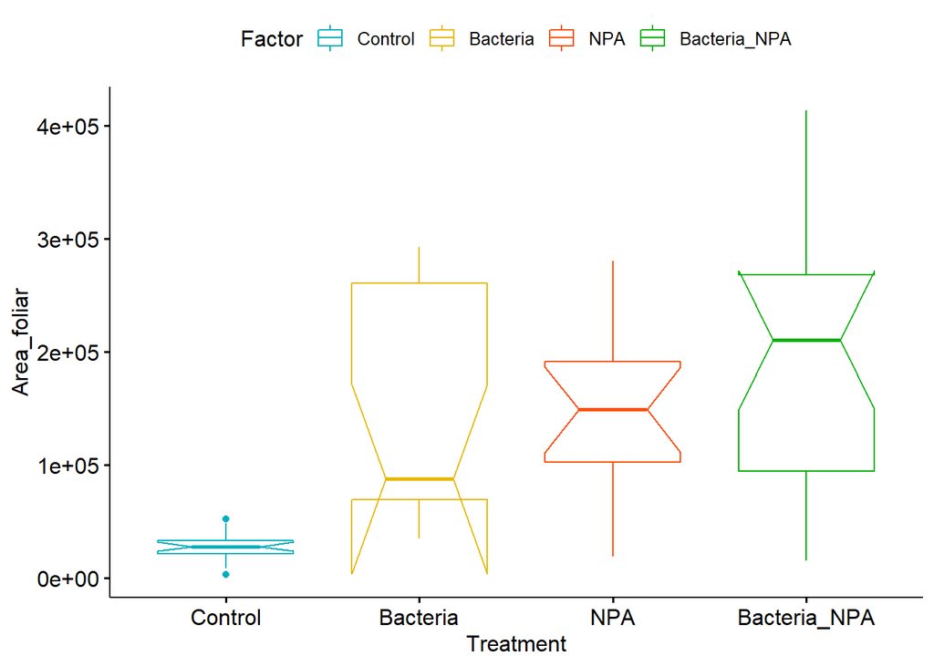

```r
p1 <- ggboxplot(db, x = "Factor", y = "Area_foliar", notch = T,
          color = "Factor", palette = c("#00AFBB", "#E7B800", "#FC4E07", "#00AF00"),
          ylab = "Area_foliar", xlab = "Treatment")

p2 <- ggboxplot(db, x = "Factor", y = "Largo_raiz",  notch = T,
          color = "Factor", palette = c("#00AFBB", "#E7B800", "#FC4E07", "#00AF00"),
          ylab = "Largo_raiz", xlab = "Treatment")
p1
```

```r
p2
```

```
## notch went outside hinges. Try setting notch=FALSE.
## notch went outside hinges. Try setting notch=FALSE.
```

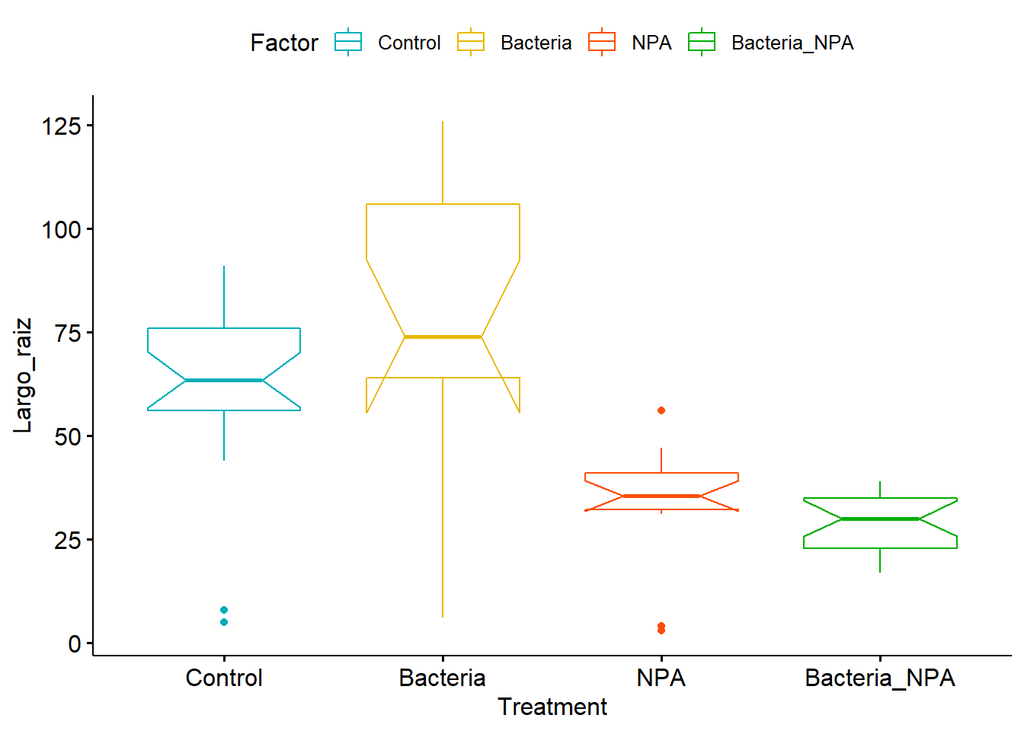

> Se observa que el área foliar es sensible a los distintos tratamientos al visualizarlos respecto al control, sin embargo, los subgrupos parecen tener dispersiones muy distintas respecto al tratamiento de control. Por otro lado, el largo de la raiz presenta diferencias significativas según el tratamiento, en este caso, el largo de la raiz es menor en las plantas tratadas con NPA y bacteria+NPA.

Se verifica la existencia de relación lineal entre área foliar y largo de la raiz

```r
lm1 <- lm(Area_foliar ~ Largo_raiz, data = db)
summary(lm1)
```

```
##
## Call:
## lm(formula = Area_foliar ~ Largo_raiz, data = db)
##
## Residuals:
##     Min      1Q  Median      3Q     Max
## -168077  -87916  -32143   72701  275277
##
## Coefficients:
##             Estimate Std. Error t value Pr(>|t|)
## (Intercept) 176225.2    26230.9   6.718 4.82e-09 ***
## Largo_raiz   -1021.3      461.5  -2.213   0.0303 *
## ---
## Signif. codes:  0 '***' 0.001 '**' 0.01 '*' 0.05 '.' 0.1 ' ' 1
##
## Residual standard error: 107900 on 67 degrees of freedom
## Multiple R-squared:  0.06811,    Adjusted R-squared:  0.0542
## F-statistic: 4.897 on 1 and 67 DF,  p-value: 0.03031
```

```r
cor.test(db$Area_foliar, db$Largo_raiz,
                    method = "pearson")
```

```
##
##  Pearson's product-moment correlation
##
## data:  db$Area_foliar and db$Largo_raiz
## t = -2.2129, df = 67, p-value = 0.03031
## alternative hypothesis: true correlation is not equal to 0
## 95 percent confidence interval:
##  -0.46871238 -0.02590335
## sample estimates:
##       cor
## -0.260984
```

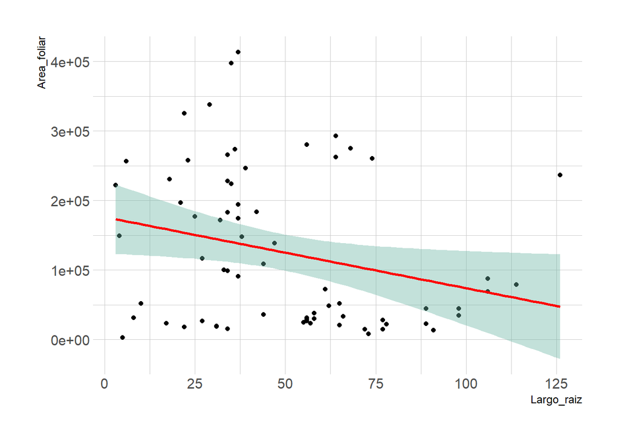

```r
ggplot(db, aes(x=Largo_raiz, y=Area_foliar)) +
  geom_point() +
  geom_smooth(method=lm , color="red", fill="#69b3a2", se=TRUE) +
  theme_ipsum()
```

> Se puede observar que existe una correlación lineal de -0.26 entre área foliar y largo de la raiz, aunque el R cuadrado del ajuste lineal asociado es relativamente bajo (0.0542).

Se aplica Bartlett test para ver si las varianzas de los subgrupos de datos (factores) son homogéneas.

```r
bartlett.test(Area_foliar ~ Factor, data = db)
```

```
##
##  Bartlett test of homogeneity of variances
##
## data:  Area_foliar by Factor
## Bartlett's K-squared = 69.163, df = 3, p-value = 6.45e-15
```

```r
bartlett.test(Largo_raiz ~ Factor, data = db)
```

```
##
##  Bartlett test of homogeneity of variances
##
## data:  Largo_raiz by Factor
## Bartlett's K-squared = 38.765, df = 3, p-value = 1.947e-08
```

> La varianza de los subgrupos está lejos de ser homogénea, son significativamente distintas tanto para área foliar como largo de la raiz, por lo que no se cumple un supuesto importante para la fiablilidad de un ANOVA o ANCOVA.

Análisis de varianza y covarianza (ANOVA y ANCOVA) para área foliar

```r
AF_anova <- aov(Area_foliar ~ Factor, data = db)
summary(AF_anova)
```

```
##             Df    Sum Sq   Mean Sq F value  Pr(>F)
## Factor       3 3.349e+11 1.116e+11   14.44 2.6e-07 ***
## Residuals   65 5.025e+11 7.731e+09
## ---
## Signif. codes:  0 '***' 0.001 '**' 0.01 '*' 0.05 '.' 0.1 ' ' 1
```

```r
AF_ancova <- aov(Area_foliar ~ Factor*Largo_raiz, data = db)
summary(AF_ancova)
```

```
##                   Df    Sum Sq   Mean Sq F value   Pr(>F)
## Factor             3 3.349e+11 1.116e+11  14.675 2.65e-07 ***
## Largo_raiz         1 9.348e+08 9.348e+08   0.123    0.727
## Factor:Largo_raiz  3 3.755e+10 1.252e+10   1.646    0.188
## Residuals         61 4.640e+11 7.607e+09
## ---
## Signif. codes:  0 '***' 0.001 '**' 0.01 '*' 0.05 '.' 0.1 ' ' 1
```

> El tipo de tratamiento sí es significativo para las medias del área foliar pero, el largo de la raíz es no es una covariable significativa, luego, tampoco lo es efecto combinado de ambos. Se observa un nivel de significancia muy similar respecto a utilizar ANOVA de un factor y el ANCOVA con covariable largo de la raiz.

Análisis de varianza y covarianza (ANOVA y ANCOVA) para largo de la raiz

```r
LR_anova <- aov(Largo_raiz ~ Factor, data = db)
summary(LR_anova)
```

```
##             Df Sum Sq Mean Sq F value   Pr(>F)
## Factor       3  24539    8180   17.64 1.74e-08 ***
## Residuals   65  30145     464
## ---
## Signif. codes:  0 '***' 0.001 '**' 0.01 '*' 0.05 '.' 0.1 ' ' 1
```

```r
LR_ancova <- aov(Largo_raiz ~ Factor*Area_foliar, data = db)
summary(LR_ancova)
```

```
##                    Df Sum Sq Mean Sq F value   Pr(>F)
## Factor              3  24539    8180  17.215 3.26e-08 ***
## Area_foliar         1     56      56   0.118    0.732
## Factor:Area_foliar  3   1106     369   0.776    0.512
## Residuals          61  28983     475
## ---
## Signif. codes:  0 '***' 0.001 '**' 0.01 '*' 0.05 '.' 0.1 ' ' 1
```

> El tipo de tratamiento sí es significativo para las medias del largo de la raiz, pero el area foliar es no es una covariable significativa, luego, tampoco lo es efecto combinado de ambos. Se observa un nivel de significancia muy similar respecto a utilizar ANOVA de un factor y el ANCOVA con covariable area foliar, aunque el estadístico F empeora levemente al incorporar la covariable.

Comparación ANOVA - ANCOVA: Se evalúa si existen diferencias significativas entre ANOVA y ANCOVA y luego se elegirá el mejor análisis por criterio de información Akaike tanto para explicar área foliar y como largo de la raiz

```r
anova(AF_anova,AF_ancova)
```

```
## Analysis of Variance Table
##
## Model 1: Area_foliar ~ Factor
## Model 2: Area_foliar ~ Factor * Largo_raiz
##   Res.Df        RSS Df  Sum of Sq     F Pr(>F)
## 1     65 5.0249e+11
## 2     61 4.6400e+11  4 3.8489e+10 1.265 0.2936
```

```r
AIC(AF_anova,AF_ancova)
```

```
##           df      AIC
## AF_anova   5 1772.716
## AF_ancova  9 1775.217
```

```r
anova(LR_anova,LR_ancova)
```

```
## Analysis of Variance Table
##
## Model 1: Largo_raiz ~ Factor
## Model 2: Largo_raiz ~ Factor * Area_foliar
##   Res.Df   RSS Df Sum of Sq      F Pr(>F)
## 1     65 30145
## 2     61 28983  4    1162.1 0.6114  0.656
```

```r
AIC(LR_anova,LR_ancova)
```

```
##           df      AIC
## LR_anova   5 625.3115
## LR_ancova  9 630.5991
```

> No existe diferencia significativa entre incorporar o no la covariable al análisis, tanto largo de la raiz como para área foliar. Luego por criterio de información Akaike, para ambos casos obtuvo mejor desempeño el ANOVA respecto al ANCOVA, por lo que se descarta el ANCOVA para el resto del análisis.

Análisis visual de los residuos del modelo y análisis de normalidad de los residuos con test de Shapiro-Wilk para el área foliar

```r
shapiro.test(AF_anova$residuals)
```

```
##
##  Shapiro-Wilk normality test
##
## data:  AF_anova$residuals
## W = 0.96812, p-value = 0.07503
```

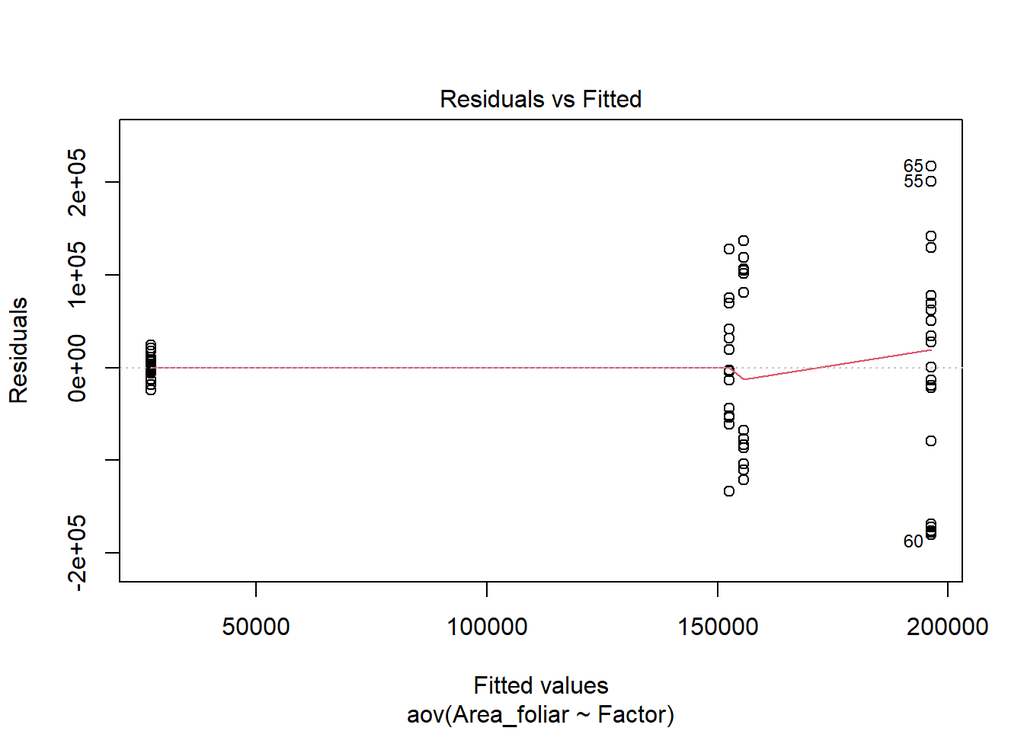

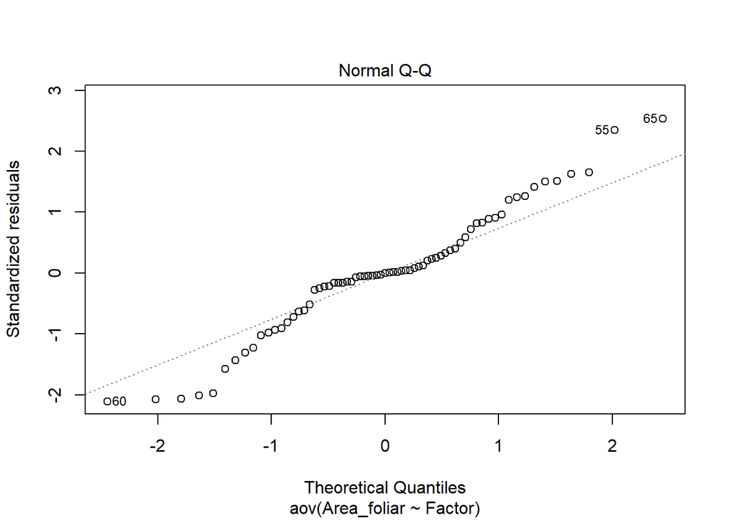

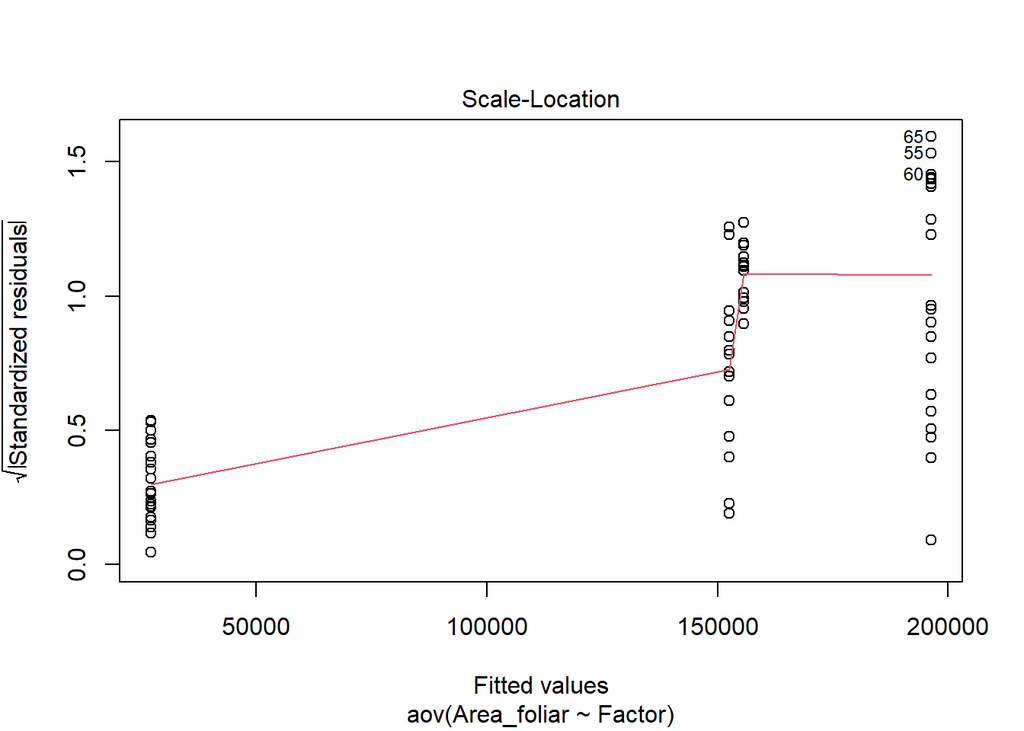

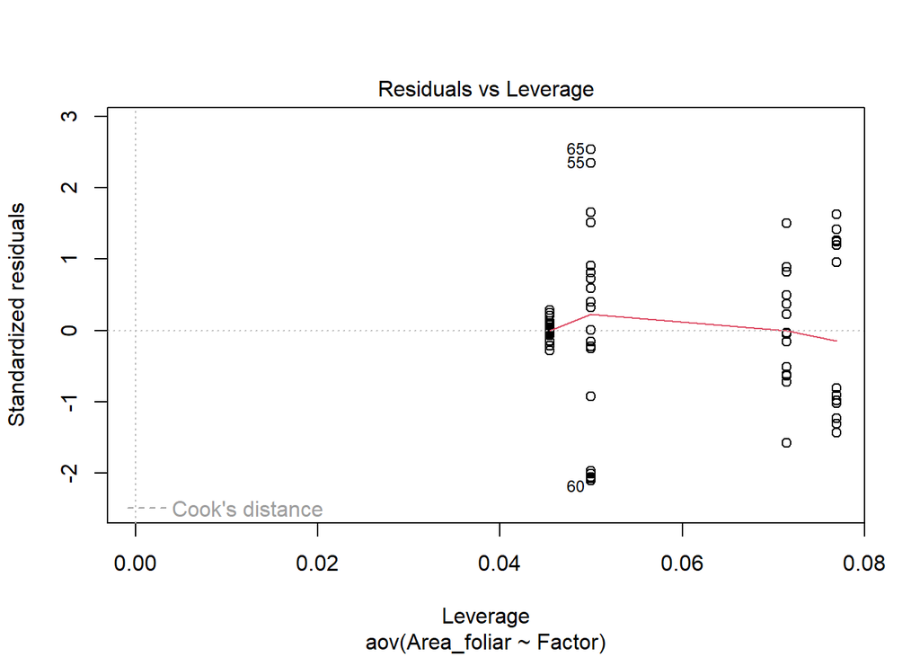

```r
plot(AF_anova)
```

Análisis visual de los residuos del modelo y análisis de normalidad de los residuos con test de Shapiro-Wilk para el largo de la raiz

```r
shapiro.test(LR_anova$residuals)
```

```
##
##  Shapiro-Wilk normality test
##
## data:  LR_anova$residuals
## W = 0.88869, p-value = 1.619e-05
```

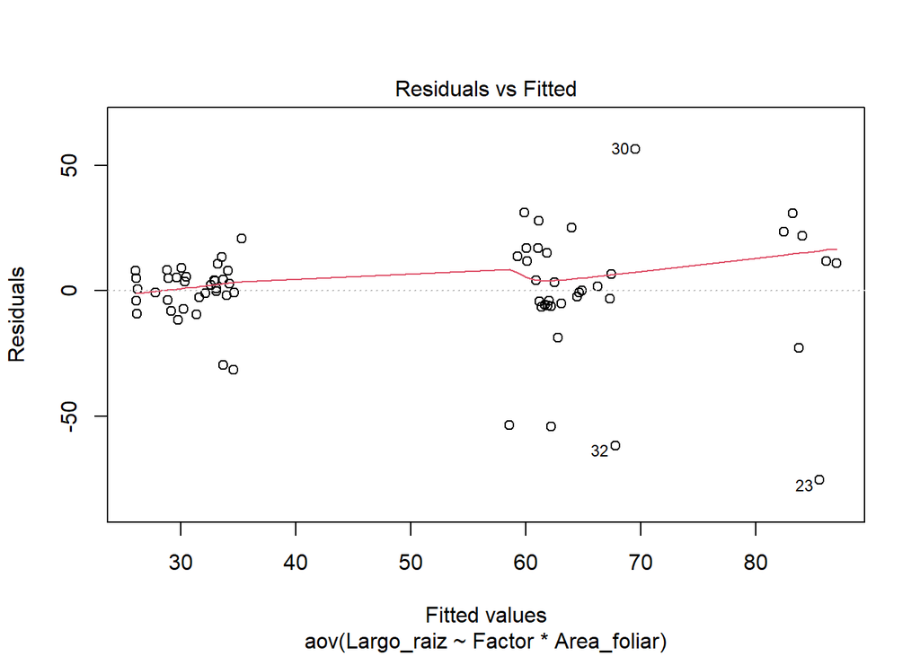

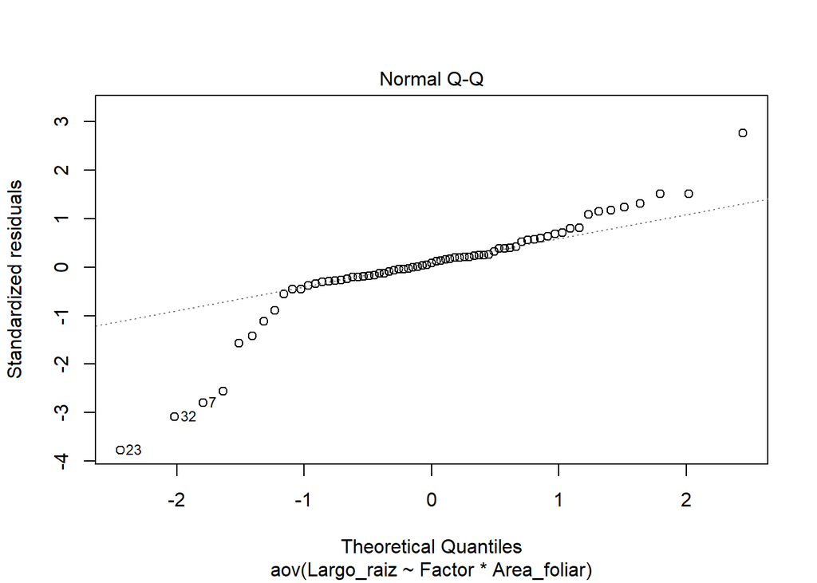

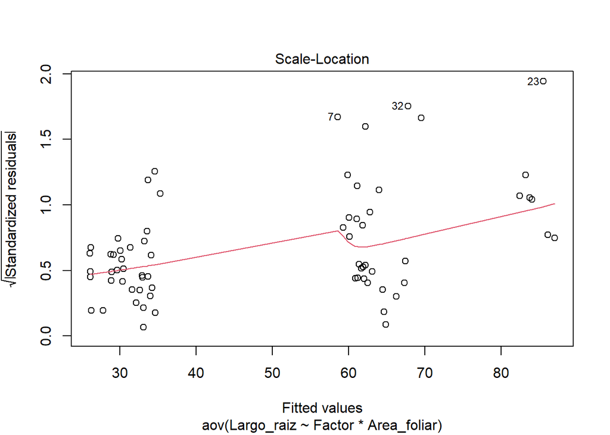

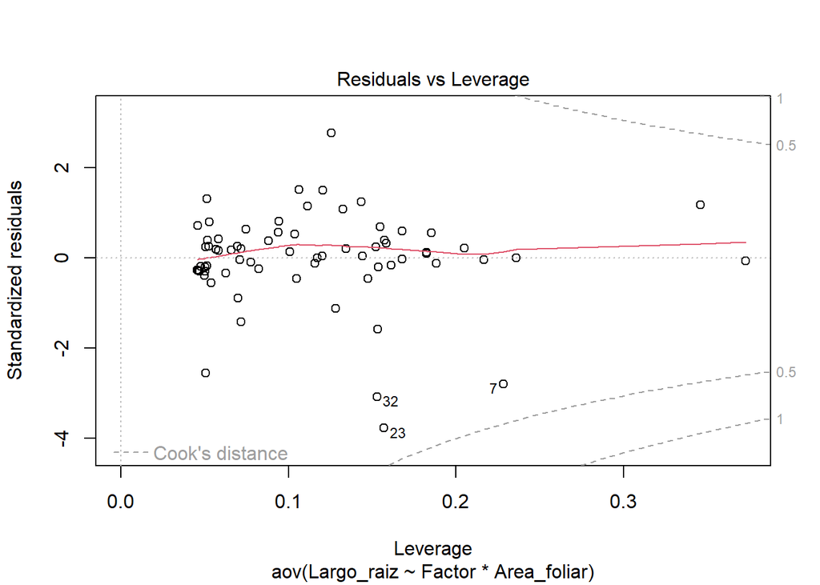

```r
plot(LR_ancova)
```

> Los residuos de los subgrupos NO parecen provenir de una distribución normal para largo de la raiz, por lo que hay dos supuestos que no se cumplen para un correcto ANOVA o ANCOVA.

Se utilizará el test no paramétrico Kruskal-Wallis ya que el tamaño de la muestra es mayor a 20 y los datos no son pareados. Kruskal para área foliar

```r
AF_kw <- kruskal.test(Area_foliar ~ Factor, data = db)
AF_kw
```

```
##
##  Kruskal-Wallis rank sum test
##
## data:  Area_foliar by Factor
## Kruskal-Wallis chi-squared = 28.805, df = 3, p-value = 2.461e-06
```

```r
summary(AF_anova)
```

```
##             Df    Sum Sq   Mean Sq F value  Pr(>F)
## Factor       3 3.349e+11 1.116e+11   14.44 2.6e-07 ***
## Residuals   65 5.025e+11 7.731e+09
## ---
## Signif. codes:  0 '***' 0.001 '**' 0.01 '*' 0.05 '.' 0.1 ' ' 1
```

> El tratamiento sí produce grupos significativamente distintos respecto a su área foliar (no provienen de una misma distribución)

Kruskal para largo de la raiz

```r
LR_kw <- kruskal.test(Largo_raiz ~ Factor, data = db)
LR_kw
```

```
##
##  Kruskal-Wallis rank sum test
##
## data:  Largo_raiz by Factor
## Kruskal-Wallis chi-squared = 32.027, df = 3, p-value = 5.165e-07
```

```r
summary(LR_anova)
```

```
##             Df Sum Sq Mean Sq F value   Pr(>F)
## Factor       3  24539    8180   17.64 1.74e-08 ***
## Residuals   65  30145     464
## ---
## Signif. codes:  0 '***' 0.001 '**' 0.01 '*' 0.05 '.' 0.1 ' ' 1
```

> El tratamiento sí produce grupos significativamente distintos respecto a su largo de la raiz (no provienen de una misma distribución)

Test post-hoc para analizar en qué grupos están las diferencias significativas.

Diferencias entre grupos para área foliar y largo de la raiz (no paramétrico) con pairwise.wilcox.test

```r
pairwise.wilcox.test(db$Area_foliar, db$Factor,
                     p.adjust.method = "bonf")
```

```
##
##  Pairwise comparisons using Wilcoxon rank sum exact test
##
## data:  db$Area_foliar and db$Factor
##
##              Bacteria Bacteria_NPA Control
## Bacteria_NPA 1.00000  -            -
## Control      5.4e-07  0.00096      -
## NPA          1.00000  1.00000      3.8e-06
##
## P value adjustment method: bonferroni
```

```r
pairwise.wilcox.test(db$Largo_raiz, db$Factor,
                     p.adjust.method = "bonf")
```

```
##
##  Pairwise comparisons using Wilcoxon rank sum test with continuity correction
##
## data:  db$Largo_raiz and db$Factor
##
##              Bacteria Bacteria_NPA Control
## Bacteria_NPA 0.00579  -            -
## Control      0.40542  3.6e-05      -
## NPA          0.00744  0.40858      0.00031
##
## P value adjustment method: bonferroni
```

```r
p1
```

```
## notch went outside hinges. Try setting notch=FALSE.
## notch went outside hinges. Try setting notch=FALSE.
```

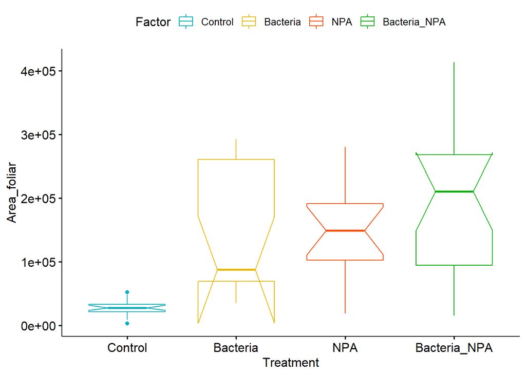

```r
p2
```

```
## notch went outside hinges. Try setting notch=FALSE.
## notch went outside hinges. Try setting notch=FALSE.
```

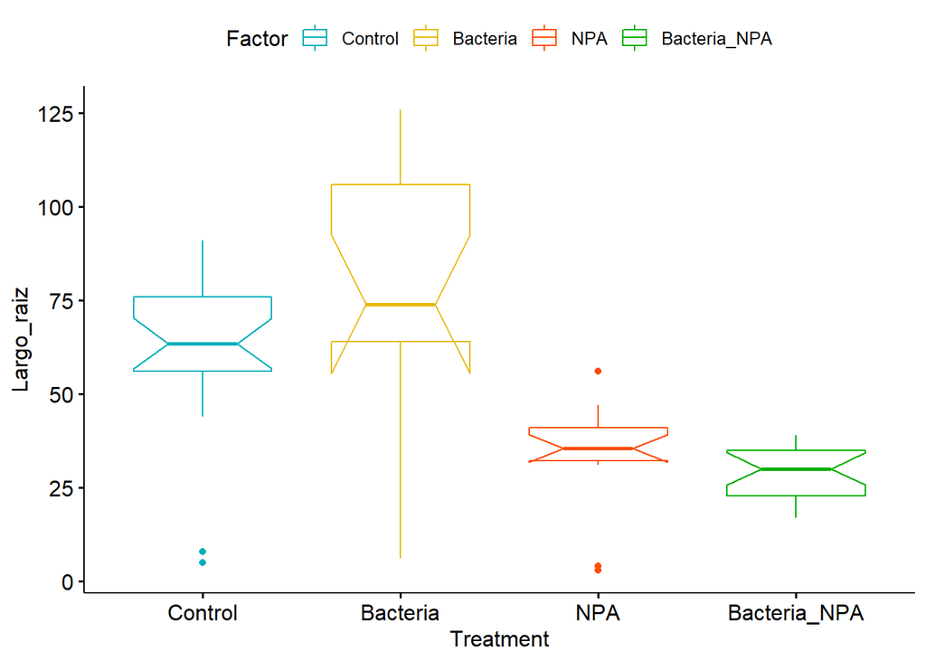

> Para área foliar: Solo existe diferencias entre los tres tratamientos y el control. Las diferencias entre los tres tratamientos no son significativas. Cabe destacar, como se aprecia en los boxplots iniciales, que los tres tratamientos fomentan el crecimiento del área foliar Para largo de la raiz: Existe diferencia significativa entre todos los pares excepto Control x Bacteria y NPA x Bacteria_NPA. Cabe destacar que ningún tratamiento supera al control significativamente para el largo de la raiz.